# Getting started with R Markdown

## R Markdown

R Markdown is a flexible type of document that allows you to seamlessly combine executable R code, and its output, with text in a single document. These documents can be readily converted to multiple static and dynamic output formats, including PDF (.pdf), Word (.docx), and HTML (.html).

The benefit of a well-prepared R Markdown document is full reproducibility. This also means that, if you notice a data transcription error, or you are able to add more data to your analysis, you will be able to recompile the report without making any changes in the actual document.

The **rmarkdown** package comes pre-installed with RStudio, so no action is necessary.

[figure not shown]

Image credit: [Allison Horst](https://github.com/allisonhorst/stats-illustrations)

## Creating an R Markdown file

To create a new R Markdown document in RStudio, click File -> New File -> R Markdown:

[figure not shown]

Screenshot of the New R Markdown file dialogue box in RStudio

Then click on ‘Create Empty Document’. Normally you could enter the title of your document, your name (Author), and select the type of output, but we will be learning how to start from a blank document.

## Basic components of R Markdown

To control the output, a YAML (YAML Ain’t Markup Language) header is needed:

```
---
title: "My Awesome Report"
author: "Emmet Brickowski"
date: ""
output: html_document
---
```

The header is defined by the three hyphens at the beginning (`---`) and the three hyphens at the end (`---`).

In the YAML, the only required field is the `output:`, which specifies the type of output you want. This can be an `html_document`, a `pdf_document`, or a `word_document`. We will start with an HTML doument and discuss the other options later.

The rest of the fields can be deleted, if you don’t need them. After the header, to begin the body of the document, you start typing after the end of the YAML header (i.e. after the second `---`).

## Markdown syntax

Markdown is a popular markup language that allows you to add formatting elements to text, such as **bold**, *italics*, and `code`. The formatting will not be immediately visible in a markdown (.md) document, like you would see in a Word document. Rather, you add Markdown syntax to the text, which can then be converted to various other files that can translate the Markdown syntax. Markdown is useful because it is lightweight, flexible, and platform independent.

Some platforms provide a real time preview of the formatting, like RStudio’s visual markdown editor (available from version 1.4).

First, let’s create a header! A `#` in front of text indicates to Markdown that this text is a header. Adding more `#`s make the header smaller, i.e. one `#` is a first level header, two `##`s is a second level header, etc.

```
# Title
## Section
### Sub-section
#### Sub-sub section
##### Sub-sub-sub section
```

Since we have already defined our title in the YAML header, we will use a section header to create an Introduction section.

```
## Introduction
```

You can make things **bold** by surrounding the word with double asterisks, `**bold**`, or double underscores, `__bold__`; and *italicize* using single asterisks, `*italics*`, or single underscores, `_italics_`.

You can also combine **bold** and *italics* to write something *really* important with triple-asterisks, `***really***`, or underscores, `___really___`; and, if you’re feeling bold (pun intended), you can also use a combination of asterisks and underscores, `**_really_**`, `**_really_**`.

To create `code-type` font, surround the word with backticks, `code-type`.

Now that we’ve learned a couple of things, it might be useful to implement them:

```
## Introduction

This report uses the **tidyverse** package along with the *SAFI* dataset,
which has columns that include:
```

Then we can create a list for the variables using `-`, `+`, or `*` keys.

```
## Introduction

This report uses the **tidyverse** package along with the *SAFI* dataset,
which has columns that include:

- village
- interview_date
- no_members
- years_liv
- respondent_wall_type
- rooms
```

You can also create an ordered list using numbers:

```
1. village
2. interview_date
3. no_members
4. years_liv
5. respondent_wall_type
6. rooms
```

And nested items by tab-indenting:

```
- village
  + Name of village
- interview_date
  + Date of interview
- no_members
  + How many family members lived in a house
- years_liv
  + How many years respondent has lived in village or neighbouring village
- respondent_wall_type
  + Type of wall of house
- rooms
  + Number of rooms in house
```

For more Markdown syntax see [the following reference guide](https://www.markdownguide.org/basic-syntax).

Now we can render the document into HTML by clicking the **Knit** button in the top of the Source pane (top left), or use the keyboard shortcut `Ctrl`+`Shift`+`K` on Windows and Linux, and `Cmd`+`Shift`+`K` on Mac. If you haven’t saved the document yet, you will be prompted to do so when you **Knit** for the first time.

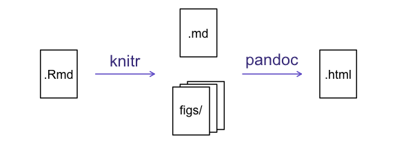

The ‘knitting’ process: First, R Markdown is converted to Markdown, which is then converted (via pandoc) to .html, .pdf, .docx, etc.

## Writing an R Markdown report

Now we will add some R code from our previous data wrangling and visualisation, which means we need to make sure **tidyverse** is loaded. It is not enough to load **tidyverse** from the console, we will need to load it within our R Markdown document. The same applies to our data. To load these, we will need to create a ‘code chunk’ at the top of our document (below the YAML header).

A code chunk can be inserted by clicking Code > Insert Chunk, or by using the keyboard shortcuts `Ctrl`+`Alt`+`I` on Windows and Linux, and `Cmd`+`Option`+`I` on Mac.

The syntax of a code chunk is:

````
```{r chunk-name}
Here is where you place the R code that you want to run.
```
````

To load **tidyverse** and our `SAFI_clean.csv` file, we will insert a chunk and call it ‘setup’. Since we don’t want this code or the output to show in our knitted HTML document, we add an `include = FALSE` option after the code chunk name (`{r setup, include = FALSE}`).

````
```{r setup, include = FALSE}
library(tidyverse)
library(here)
interviews <- read_csv(here("data/SAFI_clean.csv"), na = "NULL")
```
````

## Important Note!

> The file paths you give in a .Rmd document, e.g. to load a .csv file, are relative to the .Rmd document, **not** the project root.

> As suggested in the Starting with Data episode, we highly recommend the use of the `here()` function to keep the file paths consistent within your project.

## Insert table

Next, we will re-create a table from the Data Wrangling episode which shows the average household size grouped by `village` and `memb_assoc`. We can do this by creating a new code chunk and calling it ‘interview-tbl’. Or, you can come up with something more creative (just remember to stick to the naming rules).

It isn’t necessary to **Knit** your document every time you want to see the output. Instead you can run the code chunk with the green triangle in the top right corner of the the chunk, or with the keyboard shortcuts: `Ctrl`+`Alt`+`C` on Windows and Linux, or `Cmd`+`Option`+`C` on Mac.

To make sure the table is formatted nicely in our output document, we will need to use the `kable()` function from the **knitr** package. The `kable()` function takes the output of your R code and knits it into a nice looking HTML table. You can also specify different aspects of the table, e.g. the column names, a caption, etc.

Run the code chunk to make sure you get the desired output.

```
interviews %>%
    filter(!is.na(memb_assoc)) %>%
    group_by(village, memb_assoc) %>%
    summarize(mean_no_membrs = mean(no_membrs)) %>%
  knitr::kable(caption = "We can also add a caption.",
               col.names = c("Village", "Member Association",
                             "Mean Number of Members"))
```

We can also add a caption.

| Village | Member Association | Mean Number of Members |
| --- | --- | --- |
| Chirodzo | no | 8.062500 |
| Chirodzo | yes | 7.818182 |
| God | no | 7.133333 |
| God | yes | 8.000000 |
| Ruaca | no | 7.178571 |
| Ruaca | yes | 9.500000 |

## Customising chunk output

We mentioned using `include = FALSE` in a code chunk to prevent the code and output from printing in the knitted document. There are additional options available to customise how the code-chunks are presented in the output document. The options are entered in the code chunk after `chunk-name`and separated by commas, e.g. `{r chunk-name, eval = FALSE, echo = TRUE}`.

| Option | Options | Output |
| --- | --- | --- |
| `eval` | `TRUE` or `FALSE` | Whether or not the code within the code chunk should be run. |
| `echo` | `TRUE` or `FALSE` | Choose if you want to show your code chunk in the output document. `echo = TRUE` will show the code chunk. |
| `include` | `TRUE` or `FALSE` | Choose if the output of a code chunk should be included in the document. `FALSE` means that your code will run, but will not show up in the document. |
| `warning` | `TRUE` or `FALSE` | Whether or not you want your output document to display potential warning messages produced by your code. |
| `message` | `TRUE` or `FALSE` | Whether or not you want your output document to display potential messages produced by your code. |
| `fig.align` | `default`, `left`, `right`, `center` | Where the figure from your R code chunk should be output on the page |

## In-line R code

Now we will use some in-line R code to present some descriptive statistics. To use in-line R-code, we use the same backticks that we used in the Markdown section, with an `r` to specify that we are generating R-code. The difference between in-line code and a code chunk is the number of backticks. In-line R code uses one backtick (`` `r` ``), whereas code chunks use three backticks (``` r ```).

For example, today’s date is `r Sys.Date()`, will be rendered as: today’s date is 2022-01-21.  
The code will display today’s date in the output document (well, technically the date the document was last knitted).

The best way to use in-line R code, is to minimise the amount of code you need to produce the in-line output by preparing the output in code chunks. Let’s say we’re interested in presenting the average household size in a village.

```
# create a summary data frame with the mean household size by village
mean_household <- interviews %>%
    group_by(village) %>%
    summarize(mean_no_membrs = mean(no_membrs))

# and select the village we want to use
mean_chirodzo <- mean_household %>%
  filter(village == "Chirodzo")
```

Now we can make an informative statement on the means of each village, and include the mean values as in-line R-code. For example:

The average household size in the village of Chirodzo is `r round(mean_chirodzo$mean_no_members, 2)`

becomes…

The average household size in the village of Chirodzo is 7.08.

Because we are using in-line R code instead of the actual values, we have created a dynamic document that will automatically update if we make changes to the dataset and/or code chunks.

## Plots

Finally, we will also include a plot, so our document is a little more colourful and a little less boring. We will use the `interview_plotting` data from the previous episode.

If you were unable to complete the previous lesson or did not save the data, then you can create it in a new code chunk.

```
## Not run, but can be used to load in data from previous lesson!
interviews_plotting <- interviews %>%
  ## pivot wider by items_owned
  separate_rows(items_owned, sep = ";") %>%
  ## if there were no items listed, changing NA to no_listed_items
  replace_na(list(items_owned = "no_listed_items")) %>%
  mutate(items_owned_logical = TRUE) %>%
  pivot_wider(names_from = items_owned,
              values_from = items_owned_logical,
              values_fill = list(items_owned_logical = FALSE)) %>%
  ## pivot wider by months_lack_food
  separate_rows(months_lack_food, sep = ";") %>%
  mutate(months_lack_food_logical = TRUE) %>%
  pivot_wider(names_from = months_lack_food,
              values_from = months_lack_food_logical,
              values_fill = list(months_lack_food_logical = FALSE)) %>%
  ## add some summary columns
  mutate(number_months_lack_food = rowSums(select(., Jan:May))) %>%
  mutate(number_items = rowSums(select(., bicycle:car)))
```

We can also create a caption with the chunk option `fig.cap`.

````
```{r chunk-name, fig.cap = "I made this plot while attending an
awesome Data Carpentries workshop where I learned a ton of cool stuff!"}
Code for plot
```
````

…or, ideally, something more informative.

```
interviews_plotting %>%
  ggplot(aes(x = respondent_wall_type)) +
  geom_bar(aes(fill = village), position = "dodge") +
  labs(x = "Type of Wall in Home", y = "Count", fill = "Village Name") +
  scale_fill_viridis_d() # add colour deficient friendly palette
```

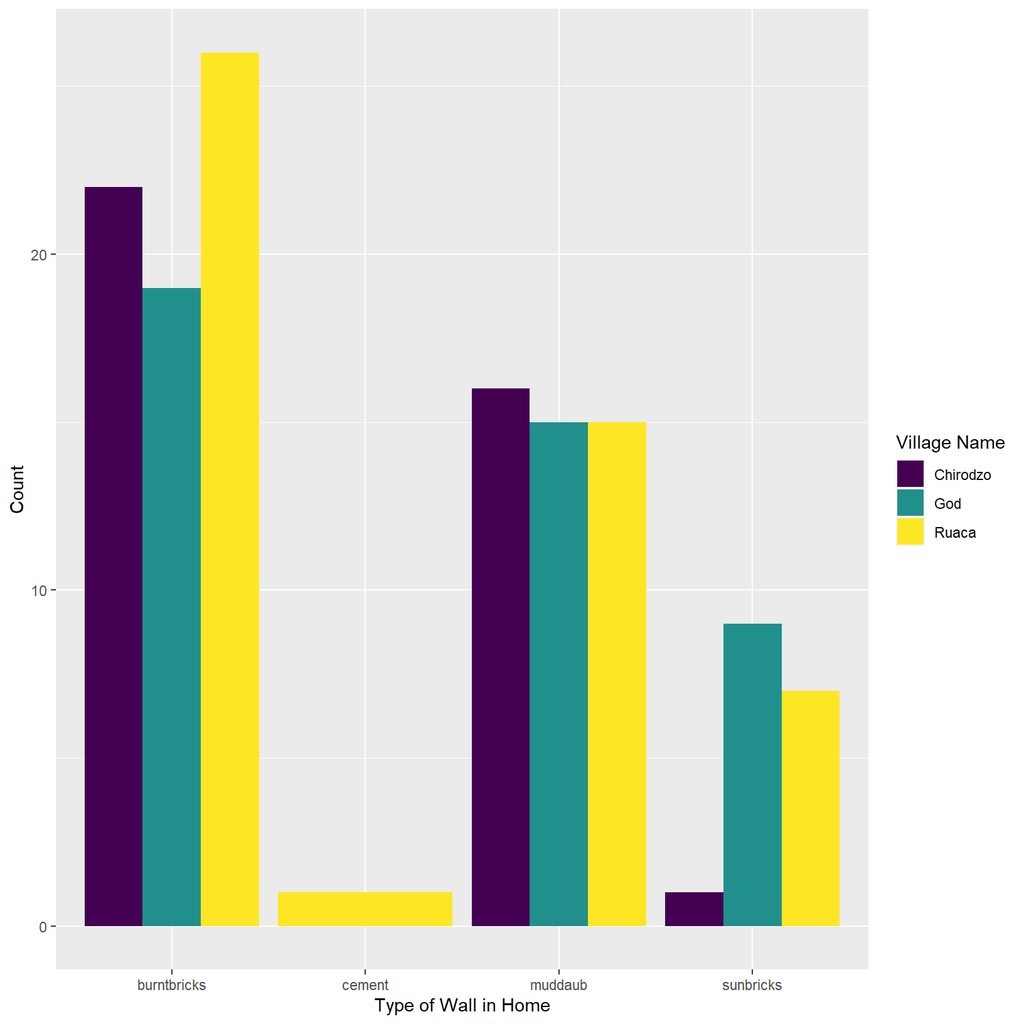

I made this plot while attending an awesome Data Carpentries workshop where I learned a ton of cool stuff!

## Other output options

You can convert R Markdown to a PDF or a Word document (among others). Click the little triangle next to the **Knit** button to get a drop-down menu. Or you could put `pdf_document` or `word_document` in the initial header of the file.

```
---
title: "My Awesome Report"
author: "Emmet Brickowski"
date: ""
output: word_document
---
```

## Note: Creating PDF documents

> Creating .pdf documents may require installation of some extra software. The R package `tinytex` provides some tools to help make this process easier for R users. With `tinytex` installed, run `tinytex::install_tinytex()` to install the required software (you’ll only need to do this once) and then when you **Knit** to pdf `tinytex` will automatically detect and install any additional LaTeX packages that are needed to produce the pdf document. Visit the [tinytex website](https://yihui.org/tinytex/) for more information.

## References

References are another area of document preparation where automation is really helpful. References in `knitr` are handled with BibTeX files (.bib). BibTeX is a reasonably standard reference citation format that can be produced by most reference managers and online services. We’ve provided the bibliography file `oajournals.bib` for you to work with.

References are handled in the `bibliography` section of the YAML header. Add the following to the YAML in the document:

```
bibliography: oajournals.bib
```

This tells `knitr` to use the `oajournals.bib` file for citations in the document.

Let’s open the `oajournals.bib` file and see what it looks like. You’ll see citation information about each article in groups indicated by a document type tag, e.g., `@article`, followed by a unique citation key (typically the last name of an author and the year of publication, e.g. Young_2015), followed by citation information. If you look at the exercise document, you’ll note that all of the citations have thus far been written manually (e.g., Castro et al (2017)). We’ll want to replace them by these (machine readable) document type tags that `knitr` will be able to combine into a Reference List at the end of the report. We use the **@** symbol to indicate a reference, so we need to replace each reference with the appropriate tag, for example `@Vasilevsky_2017`.

The reference list will automatically added to the end of the document. You’ll notice that `Vasilevsky_2017` showed up in the text as `n.d.`, even though it’s in the reference list. If we look in the BibTex file, we see that no authors and date are defined for this reference. `knitr` tries its best, but won’t correct or complete references if the proper data is not available in the `.bib` file.

You can fix the metadata by grabbing a .bib file from Google Scholar, PubMed, or Web of Science and copying the correct data into the `oajournals.bib` file. The reference will be corrected when you knit the document again.

The citation style defaults to Chicago. If you want a different citation style, you can download a csl style file from the [Zotero style registry](https://www.zotero.org/styles). Download your favorite citation style and put it in your directory. You add the citation style file by using the csl section of the YAML (this is a new section, like bibliography):

```
csl: american-chemical-society.csl
```

After knitting, you’ll see the citation style change.

## Embedded Sub-Documents and Math

To date we’ve been writing everything in one R Markdown document. We can actually build our document from sub-documents that `knitr` will integrate into the output. The sub-documents (aka child documents) do not have to contain a complete YAML header because they are designed to be integrated into the ‘main document’ or ‘parent’ at knit time.

To see how this works, find a document in your folder called `equations-child.Rmd`. You can see that this file has a minimal header followed by some R Markdown text. You’ll also see some equations written in LaTeX. That’s right; you can write LaTeX within an R Markdown document and it will get correctly formatted at knit time! :D

Let’s add the child document at the end of the .Rmd file You add child documents with a code chunk, and include the document location in the label, for example: `{r equations, child = "equations-child.Rmd"}`.

When you knit you get nicely formatted equations, in both HTML and Word.

Using multiple child-documents is a convenient and tidy way to manage multiple sections in a single long report. Each section can be authored and tested separately without bogging `knitr` down with one long scrolling document. Additionally, if just one section needs to be changed or updated over time, the parent-child authoring approach isolates the change to the necessary file without opening (and possibly inadvertently introducing errors) to the longer parent.

## Resources

- [Knitr in a knutshell tutorial](http://kbroman.org/knitr_knutshell)
- [Dynamic Documents with R and knitr](http://www.amazon.com/exec/obidos/ASIN/1482203537/7210-20) (book)
- [R Markdown documentation](http://rmarkdown.rstudio.com)
- [R Markdown cheat sheet](https://github.com/rstudio/cheatsheets/blob/master/rmarkdown-2.0.pdf)
- [Getting started with R Markdown](https://www.rstudio.com/resources/webinars/getting-started-with-r-markdown/)
- [Markdown tutorial](https://commonmark.org/help/tutorial/)
- [R Markdown: The Definitive Guide](https://bookdown.org/yihui/rmarkdown/) (book by Rstudio team)
- [Reproducible Reporting](https://www.rstudio.com/resources/webinars/reproducible-reporting/)
- [The Ecosystem of R Markdown](https://www.rstudio.com/resources/webinars/the-ecosystem-of-r-markdown/)
- [Introducing Bookdown](https://www.rstudio.com/resources/webinars/introducing-bookdown/)